# Table of Contents

## Travel Package Purchase Prediction

### Problem Statement

A tourism company named "Visit with us" is now planning to launch a new product i.e. Wellness Tourism Package. Wellness Tourism is defined as Travel that allows the traveler to maintain, enhance or kick-start a healthy lifestyle, and support or increase one's sense of well-being. The company wants to harness the available data of existing and potential customers to make the marketing expenditure more efficient.

### Objective

To predict whether a customer will purchase the Wellness Tourism Package

### Key questions to be answered

- What are the different factors which influence a customer to purchase a newly introduced travel package?
- What business recommendations can we give based on the analysis?
- How can we use different ensemble techniques - Bagging and Boosting to build a model to predict whether a customer will buy the Wellness Tourism Package?

### Data Description

**Customer details:**

1. CustomerID: Unique customer ID
2. ProdTaken: Whether the customer has purchased a package or not (0: No, 1: Yes)
3. Age: Age of customer
4. TypeofContact: How customer was contacted (Company Invited or Self Inquiry)
5. CityTier: City tier depends on the development of a city, population, facilities, and living standards. The categories are ordered i.e. Tier 1 > Tier 2 > Tier 3
6. Occupation: Occupation of customer
7. Gender: Gender of customer
8. NumberOfPersonVisiting: Total number of persons planning to take the trip with the customer
9. PreferredPropertyStar: Preferred hotel property rating by customer
10. MaritalStatus: Marital status of customer
11. NumberOfTrips: Average number of trips in a year by customer
12. Passport: The customer has a passport or not (0: No, 1: Yes)
13. OwnCar: Whether the customers own a car or not (0: No, 1: Yes)
14. NumberOfChildrenVisiting: Total number of children with age less than 5 planning to take the trip with the customer
15. Designation: Designation of the customer in the current organization
16. MonthlyIncome: Gross monthly income of the customer

**Customer interaction data:**

1. PitchSatisfactionScore: Sales pitch satisfaction score
2. ProductPitched: Product pitched by the salesperson
3. NumberOfFollowups: Total number of follow-ups has been done by the salesperson after the sales pitch
4. DurationOfPitch: Duration of the pitch by a salesperson to the customer

## Load and explore the dataset

### Import the necessary packages

```python
# this will help in making the Python code more structured automatically (good coding practice)
%reload_ext nb_black

# Library to suppress warnings or deprecation notes
import warnings

warnings.filterwarnings("ignore")

# Libraries to help with reading and manipulating data
import numpy as np
import pandas as pd

# libaries to help with data visualization
import matplotlib.pyplot as plt
import seaborn as sns

sns.set_theme()

# Removes the limit for the number of displayed columns
pd.set_option("display.max_columns", None)
# Sets the limit for the number of displayed rows
pd.set_option("display.max_rows", 200)

from sklearn import metrics
from sklearn.metrics import (
    f1_score,
    accuracy_score,
    recall_score,
    precision_score,
    confusion_matrix,
    classification_report,
    roc_auc_score,
)

from sklearn.linear_model import LogisticRegression
from sklearn.tree import DecisionTreeClassifier
from sklearn.ensemble import (
    BaggingClassifier,
    RandomForestClassifier,
    GradientBoostingClassifier,
    AdaBoostClassifier,
    StackingClassifier,
)
from xgboost import XGBClassifier

# Library to split data
from sklearn.model_selection import GridSearchCV, train_test_split
```

### Read the dataset

**Let's start by importing libraries we need.**

```python
# Loading dataset from excel
customer_data = pd.read_excel("./datasets/Tourism.xlsx", sheet_name="Tourism")
df = customer_data.copy()
```

### View the first and last 5 rows and sample of the dataset.

```python
df.head()
```

|  | CustomerID | ProdTaken | Age | TypeofContact | CityTier | DurationOfPitch | Occupation | Gender | NumberOfPersonVisiting | NumberOfFollowups | ProductPitched | PreferredPropertyStar | MaritalStatus | NumberOfTrips | Passport | PitchSatisfactionScore | OwnCar | NumberOfChildrenVisiting | Designation | MonthlyIncome |
| --- | --- | --- | --- | --- | --- | --- | --- | --- | --- | --- | --- | --- | --- | --- | --- | --- | --- | --- | --- | --- |
| 0 | 200000 | 1 | 41.0 | Self Enquiry | 3 | 6.0 | Salaried | Female | 3 | 3.0 | Deluxe | 3.0 | Single | 1.0 | 1 | 2 | 1 | 0.0 | Manager | 20993.0 |
| 1 | 200001 | 0 | 49.0 | Company Invited | 1 | 14.0 | Salaried | Male | 3 | 4.0 | Deluxe | 4.0 | Divorced | 2.0 | 0 | 3 | 1 | 2.0 | Manager | 20130.0 |
| 2 | 200002 | 1 | 37.0 | Self Enquiry | 1 | 8.0 | Free Lancer | Male | 3 | 4.0 | Basic | 3.0 | Single | 7.0 | 1 | 3 | 0 | 0.0 | Executive | 17090.0 |
| 3 | 200003 | 0 | 33.0 | Company Invited | 1 | 9.0 | Salaried | Female | 2 | 3.0 | Basic | 3.0 | Divorced | 2.0 | 1 | 5 | 1 | 1.0 | Executive | 17909.0 |
| 4 | 200004 | 0 | NaN | Self Enquiry | 1 | 8.0 | Small Business | Male | 2 | 3.0 | Basic | 4.0 | Divorced | 1.0 | 0 | 5 | 1 | 0.0 | Executive | 18468.0 |

```python
df.tail()
```

|  | CustomerID | ProdTaken | Age | TypeofContact | CityTier | DurationOfPitch | Occupation | Gender | NumberOfPersonVisiting | NumberOfFollowups | ProductPitched | PreferredPropertyStar | MaritalStatus | NumberOfTrips | Passport | PitchSatisfactionScore | OwnCar | NumberOfChildrenVisiting | Designation | MonthlyIncome |
| --- | --- | --- | --- | --- | --- | --- | --- | --- | --- | --- | --- | --- | --- | --- | --- | --- | --- | --- | --- | --- |
| 4883 | 204883 | 1 | 49.0 | Self Enquiry | 3 | 9.0 | Small Business | Male | 3 | 5.0 | Deluxe | 4.0 | Unmarried | 2.0 | 1 | 1 | 1 | 1.0 | Manager | 26576.0 |
| 4884 | 204884 | 1 | 28.0 | Company Invited | 1 | 31.0 | Salaried | Male | 4 | 5.0 | Basic | 3.0 | Single | 3.0 | 1 | 3 | 1 | 2.0 | Executive | 21212.0 |
| 4885 | 204885 | 1 | 52.0 | Self Enquiry | 3 | 17.0 | Salaried | Female | 4 | 4.0 | Standard | 4.0 | Married | 7.0 | 0 | 1 | 1 | 3.0 | Senior Manager | 31820.0 |
| 4886 | 204886 | 1 | 19.0 | Self Enquiry | 3 | 16.0 | Small Business | Male | 3 | 4.0 | Basic | 3.0 | Single | 3.0 | 0 | 5 | 0 | 2.0 | Executive | 20289.0 |
| 4887 | 204887 | 1 | 36.0 | Self Enquiry | 1 | 14.0 | Salaried | Male | 4 | 4.0 | Basic | 4.0 | Unmarried | 3.0 | 1 | 3 | 1 | 2.0 | Executive | 24041.0 |

```python
# Let's view sample of the data
df.sample(n=10, random_state=1)
```

|  | CustomerID | ProdTaken | Age | TypeofContact | CityTier | DurationOfPitch | Occupation | Gender | NumberOfPersonVisiting | NumberOfFollowups | ProductPitched | PreferredPropertyStar | MaritalStatus | NumberOfTrips | Passport | PitchSatisfactionScore | OwnCar | NumberOfChildrenVisiting | Designation | MonthlyIncome |
| --- | --- | --- | --- | --- | --- | --- | --- | --- | --- | --- | --- | --- | --- | --- | --- | --- | --- | --- | --- | --- |
| 3015 | 203015 | 0 | 27.0 | Company Invited | 1 | 7.0 | Salaried | Female | 4 | 6.0 | Basic | 3.0 | Married | 5.0 | 0 | 4 | 1 | 3.0 | Executive | 23042.0 |
| 1242 | 201242 | 0 | 40.0 | Self Enquiry | 3 | 13.0 | Small Business | Male | 2 | 3.0 | King | 4.0 | Single | 2.0 | 0 | 4 | 1 | NaN | VP | 34833.0 |
| 3073 | 203073 | 0 | 29.0 | Self Enquiry | 2 | 15.0 | Small Business | Male | 4 | 5.0 | Basic | 3.0 | Married | 3.0 | 0 | 2 | 0 | 2.0 | Executive | 23614.0 |
| 804 | 200804 | 0 | 48.0 | Company Invited | 1 | 6.0 | Small Business | Male | 2 | 1.0 | Super Deluxe | 3.0 | Single | 3.0 | 0 | 2 | 0 | 0.0 | AVP | 31885.0 |
| 3339 | 203339 | 0 | 32.0 | Self Enquiry | 1 | 18.0 | Small Business | Male | 4 | 4.0 | Deluxe | 5.0 | Divorced | 3.0 | 1 | 2 | 0 | 3.0 | Manager | 25511.0 |
| 3080 | 203080 | 1 | 36.0 | Company Invited | 1 | 32.0 | Salaried | Female | 4 | 4.0 | Basic | 4.0 | Married | 3.0 | 1 | 3 | 0 | 1.0 | Executive | 20700.0 |
| 2851 | 202851 | 0 | 46.0 | Self Enquiry | 1 | 17.0 | Salaried | Male | 4 | 4.0 | Basic | 3.0 | Divorced | 5.0 | 0 | 5 | 1 | 1.0 | Executive | 21332.0 |
| 2883 | 202883 | 1 | 32.0 | Company Invited | 1 | 27.0 | Salaried | Male | 4 | 4.0 | Standard | 3.0 | Divorced | 5.0 | 0 | 3 | 1 | 1.0 | Senior Manager | 28502.0 |
| 1676 | 201676 | 0 | 22.0 | Self Enquiry | 1 | 11.0 | Salaried | Male | 2 | 1.0 | Basic | 4.0 | Married | 2.0 | 1 | 4 | 1 | 0.0 | Executive | 17328.0 |
| 1140 | 201140 | 0 | 44.0 | Self Enquiry | 1 | 13.0 | Small Business | Female | 2 | 3.0 | King | 3.0 | Married | 1.0 | 1 | 4 | 1 | 1.0 | VP | 34049.0 |

**Observation:**

- `CustomerID` column is just an ID for the customer
- `Age`, `NumberOfFollowups`, `PreferredPropertyStar`, `NumberOfTrips` and `NumberOfChildrenVisiting` seem to be whole numbers but have floating point representation

### Understand the shape of the dataset.

```python
# checking for unique values in ID column
df.CustomerID.nunique()
```

```
4888
```

```python
# checking shape of the data
print(f"There are {df.shape[0]} rows and {df.shape[1]} columns.")
```

```
There are 4888 rows and 20 columns.
```

### Check the columns in the data

```python
df.index
```

```
RangeIndex(start=0, stop=4888, step=1)
```

```python
print(df.columns)
```

```
Index(['CustomerID', 'ProdTaken', 'Age', 'TypeofContact', 'CityTier',
       'DurationOfPitch', 'Occupation', 'Gender', 'NumberOfPersonVisiting',
       'NumberOfFollowups', 'ProductPitched', 'PreferredPropertyStar',
       'MaritalStatus', 'NumberOfTrips', 'Passport', 'PitchSatisfactionScore',
       'OwnCar', 'NumberOfChildrenVisiting', 'Designation', 'MonthlyIncome'],
      dtype='object')
```

### Check the data types of the columns

```python
df.info()
```

```
<class 'pandas.core.frame.DataFrame'>
RangeIndex: 4888 entries, 0 to 4887
Data columns (total 20 columns):
 #   Column                    Non-Null Count  Dtype
---  ------                    --------------  -----
 0   CustomerID                4888 non-null   int64
 1   ProdTaken                 4888 non-null   int64
 2   Age                       4662 non-null   float64
 3   TypeofContact             4863 non-null   object
 4   CityTier                  4888 non-null   int64
 5   DurationOfPitch           4637 non-null   float64
 6   Occupation                4888 non-null   object
 7   Gender                    4888 non-null   object
 8   NumberOfPersonVisiting    4888 non-null   int64
 9   NumberOfFollowups         4843 non-null   float64
 10  ProductPitched            4888 non-null   object
 11  PreferredPropertyStar     4862 non-null   float64
 12  MaritalStatus             4888 non-null   object
 13  NumberOfTrips             4748 non-null   float64
 14  Passport                  4888 non-null   int64
 15  PitchSatisfactionScore    4888 non-null   int64
 16  OwnCar                    4888 non-null   int64
 17  NumberOfChildrenVisiting  4822 non-null   float64
 18  Designation               4888 non-null   object
 19  MonthlyIncome             4655 non-null   float64
dtypes: float64(7), int64(7), object(6)
memory usage: 763.9+ KB
```

**Observations**

- There are many numeric (float and int type) and string (object type) columns in the data.
- `ProdTaken` is the dependent variable which is of type *int64*
- `Age`, `NumberOfFollowups`, `PreferredPropertyStar`, `NumberOfTrips` and `NumberOfChildrenVisiting` are of type float64.
- `TypeofContact`, `Occupation`, `Gender`, `ProductPitched`, `MaritalStatus` and `Designation` are string values and are of type object
- `Passport` and `OwnCar` have boolean values represented as 0 and 1. These variables are of type int64
- `CityTier`, `NumberOfPersonVisiting` and `PitchSatisfactionScore` are of type int64.
- `DurationOfPitch`, `MonthlyIncome` are of type float64

converting "objects" to "category" reduces the data space required to store the dataframe

### Fixing the data types

```python
cols = df.select_dtypes(["object"])
cols.columns
```

```
Index(['TypeofContact', 'Occupation', 'Gender', 'ProductPitched',
       'MaritalStatus', 'Designation'],
      dtype='object')
```

```python
for i in cols.columns:
    df[i] = df[i].astype("category")
```

```python
df.info()
```

```
<class 'pandas.core.frame.DataFrame'>
RangeIndex: 4888 entries, 0 to 4887
Data columns (total 20 columns):
 #   Column                    Non-Null Count  Dtype
---  ------                    --------------  -----
 0   CustomerID                4888 non-null   int64
 1   ProdTaken                 4888 non-null   int64
 2   Age                       4662 non-null   float64
 3   TypeofContact             4863 non-null   category
 4   CityTier                  4888 non-null   int64
 5   DurationOfPitch           4637 non-null   float64
 6   Occupation                4888 non-null   category
 7   Gender                    4888 non-null   category
 8   NumberOfPersonVisiting    4888 non-null   int64
 9   NumberOfFollowups         4843 non-null   float64
 10  ProductPitched            4888 non-null   category
 11  PreferredPropertyStar     4862 non-null   float64
 12  MaritalStatus             4888 non-null   category
 13  NumberOfTrips             4748 non-null   float64
 14  Passport                  4888 non-null   int64
 15  PitchSatisfactionScore    4888 non-null   int64
 16  OwnCar                    4888 non-null   int64
 17  NumberOfChildrenVisiting  4822 non-null   float64
 18  Designation               4888 non-null   category
 19  MonthlyIncome             4655 non-null   float64
dtypes: category(6), float64(7), int64(7)
memory usage: 564.5 KB
```

### Check for missing values

```python
# looking at which columns have the most missing values
df.isnull().sum().sort_values(ascending=False)
```

```
DurationOfPitch             251
MonthlyIncome               233
Age                         226
NumberOfTrips               140
NumberOfChildrenVisiting     66
NumberOfFollowups            45
PreferredPropertyStar        26
TypeofContact                25
Designation                   0
OwnCar                        0
PitchSatisfactionScore        0
Passport                      0
CustomerID                    0
MaritalStatus                 0
ProdTaken                     0
NumberOfPersonVisiting        0
Gender                        0
Occupation                    0
CityTier                      0
ProductPitched                0
dtype: int64
```

**Observation**:

- There are 8 columns with missing values

### Check for duplicate values

```python
df.duplicated().sum()
```

```
0
```

- There are no duplicate values in the dataset

### Summary of the dataset

```python
df.describe().T
```

|  | count | mean | std | min | 25% | 50% | 75% | max |
| --- | --- | --- | --- | --- | --- | --- | --- | --- |
| CustomerID | 4888.0 | 202443.500000 | 1411.188388 | 200000.0 | 201221.75 | 202443.5 | 203665.25 | 204887.0 |
| ProdTaken | 4888.0 | 0.188216 | 0.390925 | 0.0 | 0.00 | 0.0 | 0.00 | 1.0 |
| Age | 4662.0 | 37.622265 | 9.316387 | 18.0 | 31.00 | 36.0 | 44.00 | 61.0 |
| CityTier | 4888.0 | 1.654255 | 0.916583 | 1.0 | 1.00 | 1.0 | 3.00 | 3.0 |
| DurationOfPitch | 4637.0 | 15.490835 | 8.519643 | 5.0 | 9.00 | 13.0 | 20.00 | 127.0 |
| NumberOfPersonVisiting | 4888.0 | 2.905074 | 0.724891 | 1.0 | 2.00 | 3.0 | 3.00 | 5.0 |
| NumberOfFollowups | 4843.0 | 3.708445 | 1.002509 | 1.0 | 3.00 | 4.0 | 4.00 | 6.0 |
| PreferredPropertyStar | 4862.0 | 3.581037 | 0.798009 | 3.0 | 3.00 | 3.0 | 4.00 | 5.0 |
| NumberOfTrips | 4748.0 | 3.236521 | 1.849019 | 1.0 | 2.00 | 3.0 | 4.00 | 22.0 |
| Passport | 4888.0 | 0.290917 | 0.454232 | 0.0 | 0.00 | 0.0 | 1.00 | 1.0 |
| PitchSatisfactionScore | 4888.0 | 3.078151 | 1.365792 | 1.0 | 2.00 | 3.0 | 4.00 | 5.0 |
| OwnCar | 4888.0 | 0.620295 | 0.485363 | 0.0 | 0.00 | 1.0 | 1.00 | 1.0 |
| NumberOfChildrenVisiting | 4822.0 | 1.187267 | 0.857861 | 0.0 | 1.00 | 1.0 | 2.00 | 3.0 |
| MonthlyIncome | 4655.0 | 23619.853491 | 5380.698361 | 1000.0 | 20346.00 | 22347.0 | 25571.00 | 98678.0 |

**Observation**:

```python
df.describe(include=["category"]).T
```

|  | count | unique | top | freq |
| --- | --- | --- | --- | --- |
| TypeofContact | 4863 | 2 | Self Enquiry | 3444 |
| Occupation | 4888 | 4 | Salaried | 2368 |
| Gender | 4888 | 3 | Male | 2916 |
| ProductPitched | 4888 | 5 | Basic | 1842 |
| MaritalStatus | 4888 | 4 | Married | 2340 |
| Designation | 4888 | 5 | Executive | 1842 |

**Observation**:

- *Self Enquiry* is the most occurring type of contact. There are 2 unique values in this category.
- Occupation has 4 unique values and *Salaried* is the most occurring value.
- *Male* is the most occuring Gender. Gender has 3 unique values and *this warrants a quick check*.
- MaritalStatus has 4 unique values and *Married* is the most occurring value.
- Designation has 5 unique values and *Executive* is the frequently occurring value.
- ProductPitched has 5 unique values and *Basic* is the frequently occurring value.

**Number of unique values in each column**

```python
df.nunique()
```

```
CustomerID                  4888
ProdTaken                      2
Age                           44
TypeofContact                  2
CityTier                       3
DurationOfPitch               34
Occupation                     4
Gender                         3
NumberOfPersonVisiting         5
NumberOfFollowups              6
ProductPitched                 5
PreferredPropertyStar          3
MaritalStatus                  4
NumberOfTrips                 12
Passport                       2
PitchSatisfactionScore         5
OwnCar                         2
NumberOfChildrenVisiting       4
Designation                    5
MonthlyIncome               2475
dtype: int64
```

- We can drop 'CustomerID' column as it is an ID variable and will not add value to the model.
- More than the DurationOfPitch, PitchSatisfactionScore is more meaningful in assessing whether a pitch had positive impact on the customer. Since PitchSatisfactionScore is a better measure, we can drop "DurationOfPitch" column.

**Drop columns which are not adding any information**

```python
# drop the ID column as it does not add any value to the analysis
df.drop("CustomerID", axis=1, inplace=True)

# Product Pitched to a customer is more of an information and does not add any value to the analysis
df.drop("ProductPitched", axis=1, inplace=True)

# PitchSatisfactionScore is more meaninful measure of a pitch than Pitch Duration.
df.drop("DurationOfPitch", axis=1, inplace=True)
```

**Let's look at the unqiue values of all the categories**

```python
cols_cat = df.select_dtypes(["category"])

cols = [
    "CityTier",
    "NumberOfPersonVisiting",
    "NumberOfFollowups",
    "PreferredPropertyStar",
    "NumberOfTrips",
    "PitchSatisfactionScore",
    "NumberOfChildrenVisiting",
]
cols.extend(cols_cat.columns)
for i in cols:
    print("Unique values in", i, "are :")
    print(df[i].value_counts())
    print("*" * 50)
```

```
Unique values in CityTier are :
1    3190
3    1500
2     198
Name: CityTier, dtype: int64
Unique values in NumberOfPersonVisiting are :
3    2402
2    1418
4    1026
1      39
5       3
Name: NumberOfPersonVisiting, dtype: int64
Unique values in NumberOfFollowups are :
4.0    2068
3.0    1466
5.0     768
2.0     229
1.0     176
6.0     136
Name: NumberOfFollowups, dtype: int64
Unique values in PreferredPropertyStar are :
3.0    2993
5.0     956
4.0     913
Name: PreferredPropertyStar, dtype: int64
Unique values in NumberOfTrips are :
2.0     1464
3.0     1079
1.0      620
4.0      478
5.0      458
6.0      322
7.0      218
8.0      105
20.0       1
19.0       1
22.0       1
21.0       1
Name: NumberOfTrips, dtype: int64
Unique values in PitchSatisfactionScore are :
```

[output cut: 25 more lines]

```
Fe Male     155
Name: Gender, dtype: int64
Unique values in MaritalStatus are :
Married      2340
Divorced      950
Single        916
Unmarried     682
Name: MaritalStatus, dtype: int64
Unique values in Designation are :
Executive         1842
Manager           1732
Senior Manager     742
AVP                342
VP                 230
Name: Designation, dtype: int64
```

**Fix incorrect values in Gender**

```python
# Check the number of rows with incorrect values
df[df["Gender"] == "Fe Male"].Gender.value_counts()
```

```
Fe Male    155
Female       0
Male         0
Name: Gender, dtype: int64
```

```python
# Replace the wrong value with the correct value
df["Gender"] = df["Gender"].str.replace("Fe Male", "Female")
df.Gender.unique()
```

```
array(['Female', 'Male'], dtype=object)
```

## Exploratory Data Analysis

```python
df.info()
```

```
<class 'pandas.core.frame.DataFrame'>
RangeIndex: 4888 entries, 0 to 4887
Data columns (total 17 columns):
 #   Column                    Non-Null Count  Dtype
---  ------                    --------------  -----
 0   ProdTaken                 4888 non-null   int64
 1   Age                       4662 non-null   float64
 2   TypeofContact             4863 non-null   category
 3   CityTier                  4888 non-null   int64
 4   Occupation                4888 non-null   category
 5   Gender                    4888 non-null   object
 6   NumberOfPersonVisiting    4888 non-null   int64
 7   NumberOfFollowups         4843 non-null   float64
 8   PreferredPropertyStar     4862 non-null   float64
 9   MaritalStatus             4888 non-null   category
 10  NumberOfTrips             4748 non-null   float64
 11  Passport                  4888 non-null   int64
 12  PitchSatisfactionScore    4888 non-null   int64
 13  OwnCar                    4888 non-null   int64
 14  NumberOfChildrenVisiting  4822 non-null   float64
 15  Designation               4888 non-null   category
 16  MonthlyIncome             4655 non-null   float64
dtypes: category(4), float64(6), int64(6), object(1)
memory usage: 516.4+ KB
```

### Univariate analysis

```python
# function to plot a boxplot and a histogram along the same scale.


def histogram_boxplot(data, feature, figsize=(12, 7), kde=False, bins=None):
    """
    Boxplot and histogram combined

    data: dataframe
    feature: dataframe column
    figsize: size of figure (default (12,7))
    kde: whether to the show density curve (default False)
    bins: number of bins for histogram (default None)
    """
    f2, (ax_box2, ax_hist2) = plt.subplots(
        nrows=2,  # Number of rows of the subplot grid= 2
        sharex=True,  # x-axis will be shared among all subplots
        gridspec_kw={"height_ratios": (0.25, 0.75)},
        figsize=figsize,
    )  # creating the 2 subplots
    sns.boxplot(
        data=data, x=feature, ax=ax_box2, showmeans=True, color="lightpink"
    )  # boxplot will be created and a star will indicate the mean value of the column
    sns.histplot(
        data=data, x=feature, kde=kde, ax=ax_hist2, bins=bins, palette="winter"
    ) if bins else sns.histplot(
        data=data, x=feature, kde=kde, ax=ax_hist2
    )  # For histogram
    ax_hist2.axvline(
        data[feature].mean(), color="green", linestyle="--"
    )  # Add mean to the histogram
    ax_hist2.axvline(
        data[feature].median(), color="black", linestyle="-"
    )  # Add median to the histogram
```

#### Observations on Age

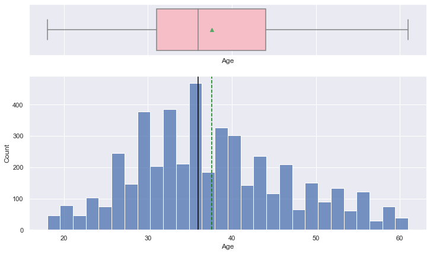

```python
histogram_boxplot(df, "Age")
```

- Age is looking normally distributed, with a hint of right skew.

#### Observations on MonthlyIncome

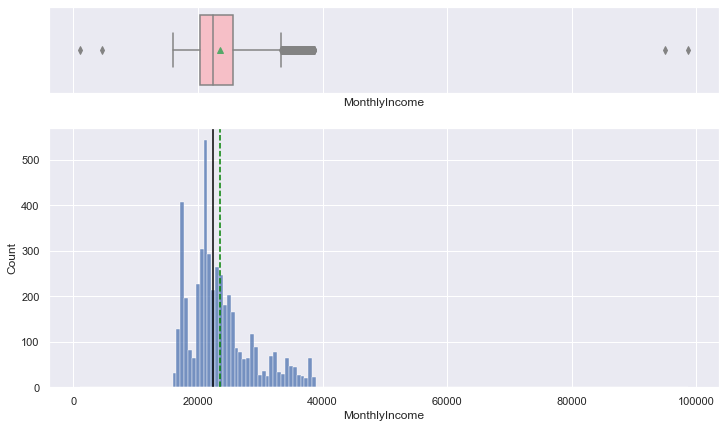

```python
histogram_boxplot(df, "MonthlyIncome")
```

- The distribution of Monthly Income is a right skewed
- The boxplot shows that there are outliers at the left and right end

#### Observations on NumberOfTrips

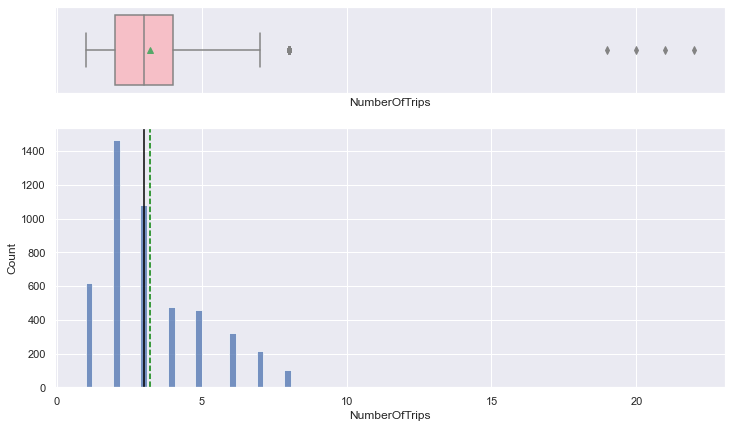

```python
histogram_boxplot(df, "NumberOfTrips")
```

- The distribution is slightly right skewed
- The boxplot shows that there are outliers at the right end

```python
# function to create labeled barplots


def labeled_barplot(data, feature, perc=False, n=None, rotation=90):
    """
    Barplot with percentage at the top

    data: dataframe
    feature: dataframe column
    perc: whether to display percentages instead of count (default is False)
    n: displays the top n category levels (default is None, i.e., display all levels)
    """

    total = len(data[feature])  # length of the column
    count = data[feature].nunique()
    if n is None:
        plt.figure(figsize=(count + 1, 5))
    else:
        plt.figure(figsize=(n + 1, 5))

    plt.xticks(rotation=rotation, fontsize=15)
    ax = sns.countplot(
        data=data,
        x=feature,
        palette="Paired",
        order=data[feature].value_counts().index[:n].sort_values(),
    )

    for p in ax.patches:
        if perc == True:
            label = "{:.1f}%".format(
                100 * p.get_height() / total
            )  # percentage of each class of the category
        else:
            label = p.get_height()  # count of each level of the category

        x = p.get_x() + p.get_width() / 2  # width of the plot
        y = p.get_height()  # height of the plot

        ax.annotate(
            label,
            (x, y),
            ha="center",
            va="center",
            size=12,
            xytext=(0, 5),
            textcoords="offset points",
        )  # annotate the percentage

    plt.show()  # show the plot
```

#### Observations on TypeofContact

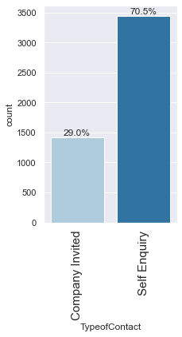

```python
labeled_barplot(df, "TypeofContact", perc=True)
```

- There are 29% company invited observations while 71% are SelfEnquiry

#### Observations on CityTier

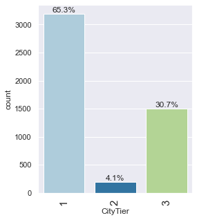

```python
labeled_barplot(df, "CityTier", perc=True)
```

#### Observations on Occupation

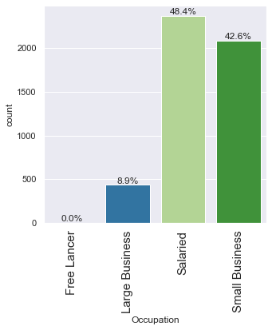

```python
labeled_barplot(df, "Occupation", perc=True)
```

- Salaried has the highest percentage of observations i.e. 48.4% followed by Small Business with 42.6%
- Large Business has 8.9% observations
- We saw earlier that "Free Lancer" has only 2 observations in the data. Here, it shows 0% observations due to rounding off.

#### Observations on Designation

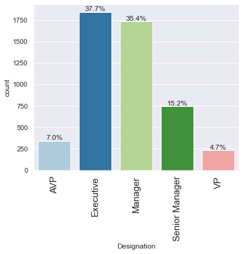

```python
labeled_barplot(df, "Designation", perc=True)
```

- 37.7% of the customers are Executives followed by 35.4% Managers

#### Observations on Gender

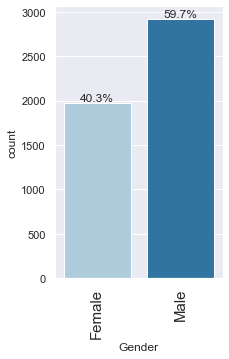

```python
labeled_barplot(df, "Gender", perc=True)
```

- 59.7% of the customers are Male while 40.3% are Female customers

#### Observations on MaritalStatus

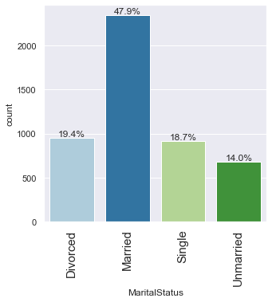

```python
labeled_barplot(df, "MaritalStatus", perc=True)
```

- Married status has the highest percentage of observations i.e. 47.9%
- Divorced and Single have approx equal number of observations in the data
- Unmarried is closely behind Divorced and Single

#### Observations on NumberOfPersonVisiting

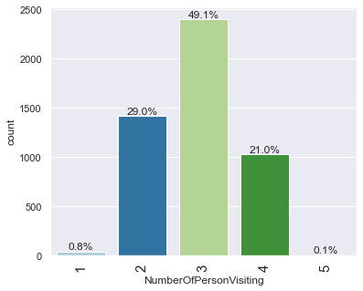

```python
labeled_barplot(df, "NumberOfPersonVisiting", perc=True)
```

- Customers who travel in a group of 3 make up 49.1% of the observations
- Customers who travel in a group of 2 and 4 people make up 29% and 21% of the observations respectively
- Customers who travel alone (1 person) and group of 5 people make up very low number of observations (39 and 3 respectively)

#### Observations on NumberOfChildrenVisiting

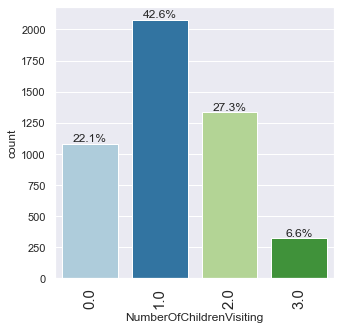

```python
labeled_barplot(df, "NumberOfChildrenVisiting", perc=True)
```

- 42.6% of the observations have 1 children less than 5 planning to take the trip with the customer
- 27.3% of the observations have 2 children less than 5 and 22.1% of the observations have 0 children planning to take the trip

#### Observations on PreferredPropertyStar

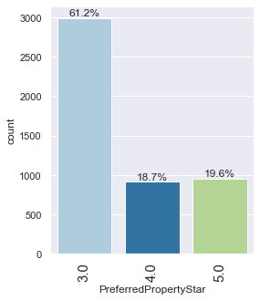

```python
labeled_barplot(df, "PreferredPropertyStar", perc=True)
```

#### Observations on Passport

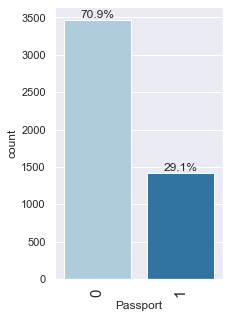

```python
labeled_barplot(df, "Passport", perc=True)
```

- 70.9% of customers do not have a passport while 29.1% have passport

#### Observations on OwnCar

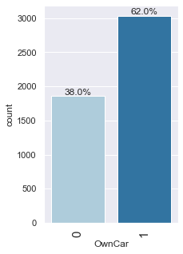

```python
labeled_barplot(df, "OwnCar", perc=True)
```

- 62% of the customers own a car while the rest 38% do not own one

#### Observations on PitchSatisfactionScore

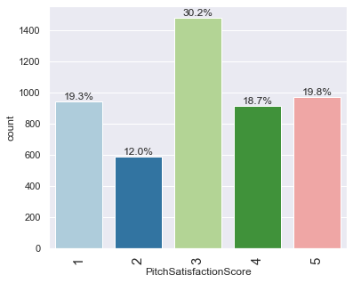

```python
labeled_barplot(df, "PitchSatisfactionScore", perc=True)
```

- 30.2% of the observations have pitch satisfaction score of 3
- Picth satisfaction score of 1, 4 and 5 have approx equal number of observations in the data

#### Observations on NumberOfFollowups

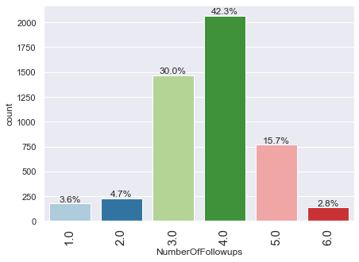

```python
labeled_barplot(df, "NumberOfFollowups", perc=True)
```

#### Observations on ProdTaken

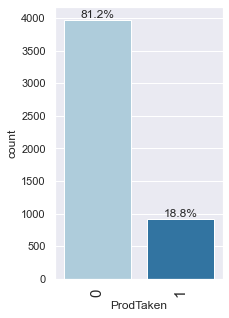

```python
labeled_barplot(df, "ProdTaken", perc=True)
```

- The class distribution in the target variable is imbalanced.
- 18.8% of the data points represent the customers who are going to purchase the package

### Bivariate Analysis

#### Correlation between numerical variables

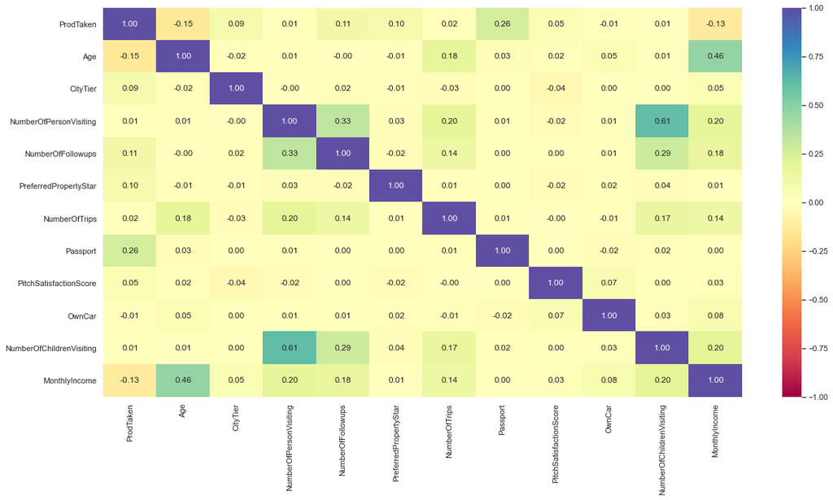

```python
plt.figure(figsize=(20, 10))
sns.heatmap(df.corr(), annot=True, vmin=-1, vmax=1, fmt=".2f", cmap="Spectral")
plt.show()
```

- Most of the variables are NOT correlated with each other
- No of persons visiting has a slight correlation with the No of children visiting which is reasonable (the more children less than 5 join, the more total ppl visiting will be)
- Age is positively correlated with Monthly Income (i.e., the older a customers is, higher the monthly income will be)
- ProdTaken is very loosely negatively correlated with Age and Monthly Income

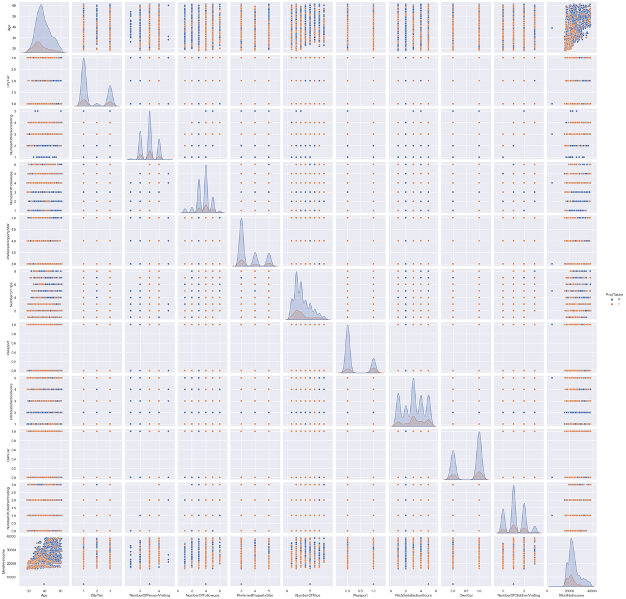

```python
sns.pairplot(df, hue="ProdTaken")
plt.show()
```

- We can see varying distributions in variables for ProdTaken, we should investigate it further.

**Let's check the variation in ProdTaken, with some of the other variables.**

```python
### function to plot distributions wrt target
def distribution_plot_wrt_target(data, predictor, target):
    plt.figure(figsize=(5, 5))
    sns.boxplot(data=data, x=target, y=predictor, palette="PuBu")
    plt.title("Boxplot w.r.t " + target)
    plt.show()
```

#### ProdTaken vs Age

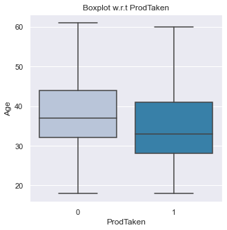

```python
distribution_plot_wrt_target(df, "Age", "ProdTaken")
```

- The median age of customers who have NOT purchased the package is more than the customers who purchased the travel package
- There are no outliers in the boxplots of both class distributions

#### ProdTaken vs MonthlyIncome

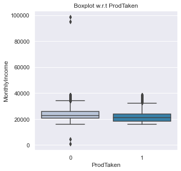

```python
distribution_plot_wrt_target(df, "MonthlyIncome", "ProdTaken")
```

- The median monthly income of customers who have NOT purchased the package is more than the customers who purchased the travel package
- There are outliers on top side for the customers who purchased the package while the outliers are on both sides for the customers who have NOT purchased the travel package

#### ProdTaken vs No of Trips

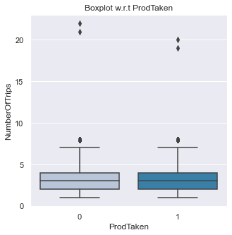

```python
distribution_plot_wrt_target(df, "NumberOfTrips", "ProdTaken")
```

- The median no of trips per year is the same for customers who have purchased and who have NOT purchased the travel package
- There are outliers on the top side of the box plot for both class distributions

```python
# function to plot stacked bar chart


def stacked_barplot(data, predictor, target):
    """
    Print the category counts and plot a stacked bar chart

    data: dataframe
    predictor: independent variable
    target: target variable
    """
    count = data[predictor].nunique()
    sorter = data[target].value_counts().index[-1]
    tab1 = pd.crosstab(data[predictor], data[target], margins=True).sort_values(
        by=sorter, ascending=False
    )
    print(tab1)
    print("-" * 100)
    tab = pd.crosstab(data[predictor], data[target], normalize="index").sort_values(
        by=sorter, ascending=False
    )
    tab.plot(kind="bar", stacked=True, figsize=(count + 1, 5))
    plt.legend(
        loc="lower left", frameon=False,
    )
    plt.legend(loc="upper left", bbox_to_anchor=(1, 1))
    plt.show()
```

#### ProdTaken vs TypeofContact

```
ProdTaken           0    1   All
TypeofContact
All              3946  917  4863
Self Enquiry     2837  607  3444
Company Invited  1109  310  1419
----------------------------------------------------------------------------------------------------
```

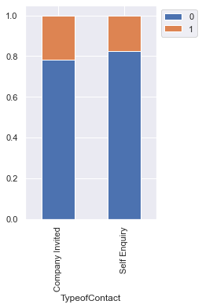

```python
stacked_barplot(df, "TypeofContact", "ProdTaken")
```

- There are more Self Enquired customers (in absolute numbers) who purchased the travel package compared to the Company invited customers
- There are approx 22% of Company invited customers who purchased the travel package compared to ~19% of self enquired customers

#### ProdTaken vs CityTier

```
ProdTaken     0    1   All
CityTier
All        3968  920  4888
1          2670  520  3190
3          1146  354  1500
2           152   46   198
----------------------------------------------------------------------------------------------------
```

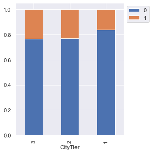

```python
stacked_barplot(df, "CityTier", "ProdTaken")
```

- There is similar percentage of people who purchased travel package in Tier2 and Tier3 cities and this percentage is more than Tier1 cities
- In terms of absolute numbers, Tier1 cities have purchased more travel package than tier2 and tier3 cities combined.

#### ProdTaken vs Occupation

```
ProdTaken          0    1   All
Occupation
All             3968  920  4888
Salaried        1954  414  2368
Small Business  1700  384  2084
Large Business   314  120   434
Free Lancer        0    2     2
----------------------------------------------------------------------------------------------------
```

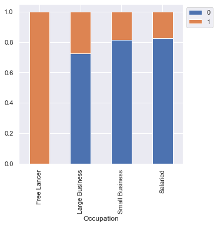

```python
stacked_barplot(df, "Occupation", "ProdTaken")
```

- Compared to other occupation groups, free lancers tend to travel a lot and hence purchase travel package more
- 30% of the Large Business customers have purchased travel package when compared to approx 20% of Small Business and Salaried customers

#### ProdTaken vs Designation

```
ProdTaken          0    1   All
Designation
All             3968  920  4888
Executive       1290  552  1842
Manager         1528  204  1732
Senior Manager   618  124   742
AVP              322   20   342
VP               210   20   230
----------------------------------------------------------------------------------------------------
```

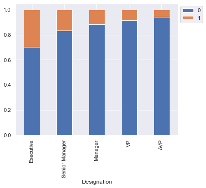

```python
stacked_barplot(df, "Designation", "ProdTaken")
```

- Executives followed by Senior Managers and Managers purchase more travel package
- Low percentage of VP and AVP purchase travel package

#### ProdTaken vs Gender

```
ProdTaken     0    1   All
Gender
All        3968  920  4888
Male       2338  578  2916
Female     1630  342  1972
----------------------------------------------------------------------------------------------------
```

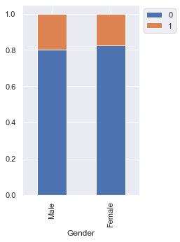

```python
stacked_barplot(df, "Gender", "ProdTaken")
```

- There are approx equal percentage of male and female customers who purchase a travel package

#### ProdTaken vs MaritalStatus

```
ProdTaken         0    1   All
MaritalStatus
All            3968  920  4888
Married        2014  326  2340
Single          612  304   916
Unmarried       516  166   682
Divorced        826  124   950
----------------------------------------------------------------------------------------------------
```

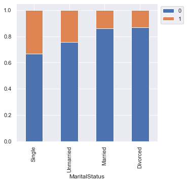

```python
stacked_barplot(df, "MaritalStatus", "ProdTaken")
```

- Higher percentage of Single followed by Unmarried customers purchase Travel Package

#### ProdTaken vs NumberOfPersonVisiting

```
ProdTaken                  0    1   All
NumberOfPersonVisiting
All                     3968  920  4888
3                       1942  460  2402
2                       1151  267  1418
4                        833  193  1026
1                         39    0    39
5                          3    0     3
----------------------------------------------------------------------------------------------------
```

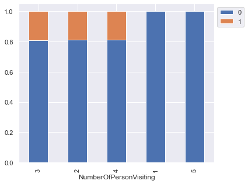

```python
stacked_barplot(df, "NumberOfPersonVisiting", "ProdTaken")
```

- Equal percentage of customers in 2,3 and 4 people travel group purchase travel package
- Customers in 1 and 5 people travel group have not purchased any travel package. Company should investigate why they have not purchased any travel package.

#### ProdTaken vs NumberOfChildrenVisiting

```
ProdTaken                    0    1   All
NumberOfChildrenVisiting
All                       3909  913  4822
1.0                       1688  392  2080
2.0                       1082  253  1335
0.0                        880  202  1082
3.0                        259   66   325
----------------------------------------------------------------------------------------------------
```

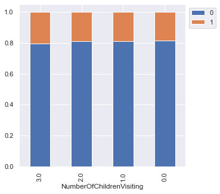

```python
stacked_barplot(df, "NumberOfChildrenVisiting", "ProdTaken")
```

- Amongst the customers who have bought travel package, there are Equal percentage of 0, 1, 2 and 3 children under age of 5 who plan to travel with the customer

#### ProdTaken vs PreferredPropertyStar

```
ProdTaken                 0    1   All
PreferredPropertyStar
All                    3948  914  4862
3.0                    2511  482  2993
5.0                     706  250   956
4.0                     731  182   913
----------------------------------------------------------------------------------------------------
```

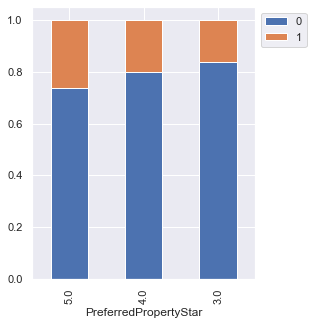

```python
stacked_barplot(df, "PreferredPropertyStar", "ProdTaken")
```

- Higher percentage of 5 star property preferring customers purchased travel package compared to 4-star and 3-star preferring customers.

#### ProdTaken vs Passport

```
ProdTaken     0    1   All
Passport
All        3968  920  4888
1           928  494  1422
0          3040  426  3466
----------------------------------------------------------------------------------------------------
```

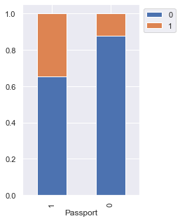

```python
stacked_barplot(df, "Passport", "ProdTaken")
```

- Approx 35% of customers who have passports have purchased Travel Package compared to 10% of customers without passports